# zuoye1

```python
import platform
import datetime
import sys
import os


your_name, your_code, work_counter = "杜培博", 200507340136, 8
print(f'我是：{your_name}，学号：{your_code}，这是我的第 {work_counter} 次作业。')
print('现在是', datetime.datetime.now())
print('我的机器信息如下：')
print(platform.uname())

print('\n当前工作目录：')
print(os.getcwd())
print('\n当前目录的文件信息如下：')
print(os.listdir())
print('\n我安装包的情况:')
!pip list
```

[output not shown]

[output cut: 111 more lines]

[output not shown]

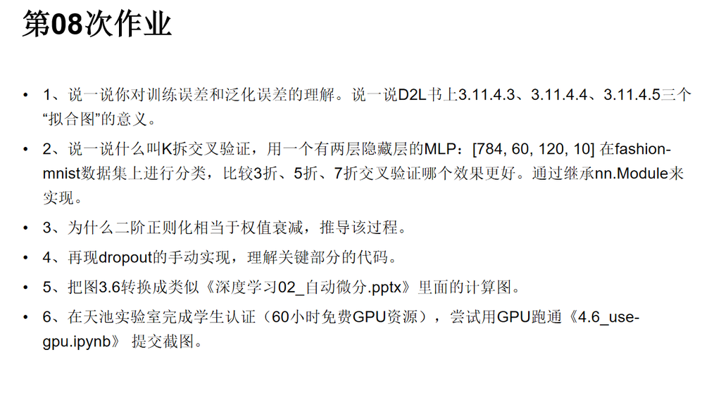

## 1、说一说你对训练误差和泛化误差的理解。说一说D2L书上3.11.4.3、3.11.4.4、3.11.4.5三个“拟合图”的意义

训练误差：在训练数据集上表现出的误差

泛化误差：在任意⼀个测试数据样本上表现出的误差的期望

拿考试来举例子：训练误差就是学生刷题时的错误率，泛化误差就是学生考试做题的错误率

拟合图：3.11.4.3：loss正常的走势，随着训练误差的减小，测试误差也在减小

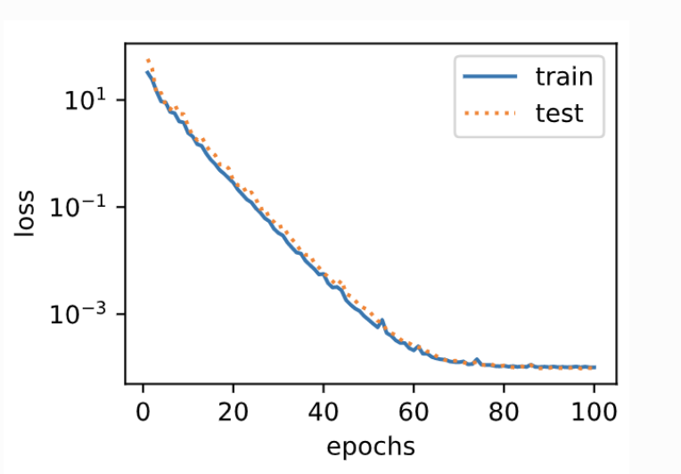

拟合图：3.11.4.4：欠拟合，在训练集和测试集上表现都不好，可能是数据少或模型复杂度低

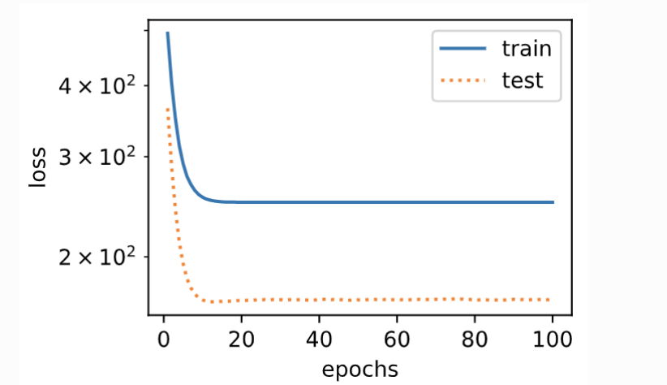

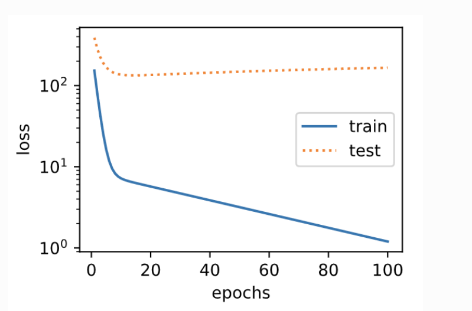

K拆交叉验证就是把训练集分成k分，拿k-1来进行训练，拿一份来验证，循环k次，一般最后平均K次的结果

## 首先我们要手写一个两个隐藏层的MLP网络

```python
# 导入包
import torch
import torch.nn as nn
import numpy as np
import d2lzh_pytorch as d2l
```

```python
# 定义输入输出
num_inputs = 784
num_outputs = 10
```

```python
## 直接从d2l加载数据
bacth_size = 10
train, test = d2l.load_data_fashion_mnist(bacth_size)
```

```python
## 继承nn.Module来实现模型
class MLP_net(nn.Module):
    def __init__(self, n_feature):
        super(MLP_net, self).__init__()
        self.hidden1 = nn.Linear(n_feature, 60)
        self.hidden2 = nn.Linear(60, 120)
        self.result = nn.Linear(120, 10)


    def forward(self, x):
        hidd1 = self.hidden1(x)
        hidd2 = self.hidden2(hidd1)
        y = self.result(hidd2)
        return y
# 实例化一下
net = MLP_net(num_inputs)
print(net)     # 我们可以看到输出的网络，一共三层，符合[784, 60, 120, 10]
```

```
MLP_net(
  (hidden1): Linear(in_features=784, out_features=60, bias=True)
  (hidden2): Linear(in_features=60, out_features=120, bias=True)
  (result): Linear(in_features=120, out_features=10, bias=True)
)
```

## 学以致用

```python
# 我们还可以添加Rule激活函数,在最后添加sigmoid函数
## 继承nn.Module来实现模型
class MLP_net(nn.Module):
    # init
    def __init__(self, n_feature):
        super(MLP_net, self).__init__()
        self.hidden1 = nn.Linear(n_feature, 60)
        self.hidden2 = nn.Linear(60, 120)
        self.result = nn.Linear(120, 10)

    # forward
    def forward(self, x):
        hidd1 = nn.functional.relu(self.hidden1(x))
        hidd2 = nn.functional.relu(self.hidden2(hidd1))
        y = torch.sigmoid(self.result(hidd2))
        return y
# 实例化一下
net = MLP_net(num_inputs)
print(net)     # 我们可以看到输出的网络，一共三层，符合[784, 60, 120, 10]
```

```
MLP_net(
  (hidden1): Linear(in_features=784, out_features=60, bias=True)
  (hidden2): Linear(in_features=60, out_features=120, bias=True)
  (result): Linear(in_features=120, out_features=10, bias=True)
)
```

```python
# 我们还可以添加Rule激活函数,在最后添加sigmoid函数
## 继承nn.Module来实现模型
class MLP_net(nn.Module):
    # init
    def __init__(self, n_feature):
        super(MLP_net, self).__init__()
        self.hidden1 = nn.Linear(n_feature, 60)
        self.hidden2 = nn.Linear(60, 120)
        self.result = nn.Linear(120, 10)

    # forward
    def forward(self, x):
        hidd1= nn.functional.dropout(nn.functional.relu(self.hidden1(x)),p=0.5)
        hidd2 = nn.functional.dropout(nn.functional.relu(self.hidden2(hidd1)),p=0.5)
        y = torch.sigmoid(self.result(hidd2))
        return y
# 实例化一下
net = MLP_net(num_inputs)
print(net)     # 我们可以看到输出的网络，一共三层，符合[784, 60, 120, 10]
```

```
MLP_net(
  (hidden1): Linear(in_features=784, out_features=60, bias=True)
  (hidden2): Linear(in_features=60, out_features=120, bias=True)
  (result): Linear(in_features=120, out_features=10, bias=True)
)
```

```python
## 方便简洁，直接调佣损失函数
loss = nn.CrossEntropyLoss()
```

```python
# 定义一个优化器
optimizer = torch.optim.SGD(net.parameters(), lr=0.1)
```

```python
num_epoch = 3
## 开始训练
for epoch in range(num_epoch):
    train_l_sum,train_acc_sum = 0.0,0.0
    for x, y in train:
        # print(type(x.view(-1,784).shape))
        y_pre = net(x.view(-1, 784))
        # print(y_pre)
        l = loss(y_pre, y).sum()
        # print(l)

        optimizer.zero_grad()
        l.backward()
        optimizer.step()

        train_l_sum += l.item()
        train_acc_sum += (y_pre.argmax(dim=1) ==y).sum().item()
        sum = y.shape[0]
#     print(train_l_sum/len(train))
    print('epoch:'+ str(epoch + 1), 'loss:'+str(train_l_sum/len(train)))
```

```
epoch:1 loss:1.8016488509376845
epoch:2 loss:1.727788316488266
epoch:3 loss:1.7062712618509928
```

```python
num_epoch = 5
## 开始训练
for epoch in range(num_epoch):
    train_l_sum,train_acc_sum = 0.0,0.0
    for x, y in train:
        # print(type(x.view(-1,784).shape))
        y_pre = net(x.view(-1, 784))
        # print(y_pre)
        l = loss(y_pre, y).sum()
        # print(l)

        optimizer.zero_grad()
        l.backward()
        optimizer.step()

        train_l_sum += l.item()
        train_acc_sum += (y_pre.argmax(dim=1) ==y).sum().item()
        sum = y.shape[0]
#     print(train_l_sum/len(train))
    print('epoch:'+ str(epoch + 1), 'loss:'+str(train_l_sum/len(train)))
```

```
epoch:1 loss:1.7613540514310202
epoch:2 loss:1.68475238297383
epoch:3 loss:1.6712763774196306
epoch:4 loss:1.6650858183701833
epoch:5 loss:1.6623216490944226
```

```python
num_epoch = 7
## 开始训练
for epoch in range(num_epoch):
    train_l_sum,train_acc_sum = 0.0,0.0
    for x, y in train:
        # print(type(x.view(-1,784).shape))
        y_pre = net(x.view(-1, 784))
        # print(y_pre)
        l = loss(y_pre, y).sum()
        # print(l)

        optimizer.zero_grad()
        l.backward()
        optimizer.step()

        train_l_sum += l.item()
        train_acc_sum += (y_pre.argmax(dim=1) ==y).sum().item()
        sum = y.shape[0]
#     print(train_l_sum/len(train))
    print('epoch:'+ str(epoch + 1), 'loss:'+str(train_l_sum/len(train)))
```

```
epoch:1 loss:1.799793797870477
epoch:2 loss:1.7166176672975222
epoch:3 loss:1.70560529645284
epoch:4 loss:1.6988358202377956
epoch:5 loss:1.6964973509907721
epoch:6 loss:1.6914298534790675
epoch:7 loss:1.665908975481987
```

## 3、为什么二阶正则化相当于权值衰减，推导该过程。

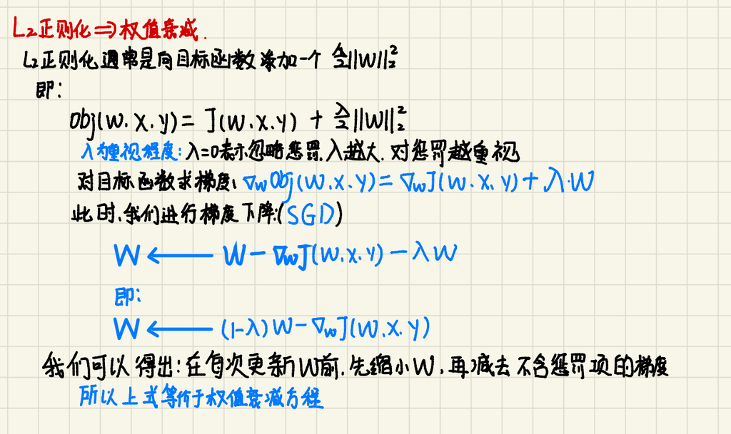

## 4、再现dropout的手动实现，理解关键部分的代码。

```python
# 导入包
%matplotlib inline
import torch
import torch.nn as nn
import numpy as np
import sys
sys.path.append("..")
import d2lzh_pytorch as d2l
```

```python
# 定义dropout函数,drop_p为要删除的概率(比例),而keep_p就是所要保存的比利
def dropout(data, drop_p):
    data = data.float()
    # 断言式
    assert 0 <= drop_p <= 1
    # 获得保存率
    keep_p = 1 - drop_p
    # 这种情况是全部丢弃
    if keep_p == 0:
        return torch.zeros_like(data)
    # 根据keep_p选取数据，选取随机数小于keep_p的保留
    mask = (torch.randn(data.shape) < keep_p).float()

    return mask * data / keep_p
```

```python
X = torch.arange(16).view(2, 8)
dropout(X, 0)
```

```
tensor([[ 0.,  1.,  2.,  3.,  0.,  5.,  6.,  0.],
        [ 8.,  0.,  0., 11.,  0., 13., 14., 15.]])
```

## 5、把图3.6转换成类似《深度学习02_自动微分.pptx》里面的计算图。

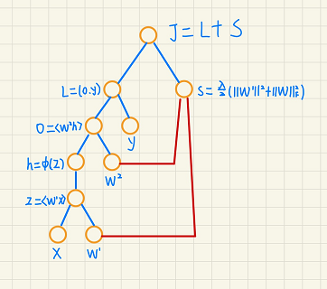

## 6、在天池实验室完成学生认证（60小时免费GPU资源），尝试用GPU跑通《4.6_use-gpu.ipynb》 提交截图。

### 天池的GPU认证之后，等好久等不到

[figure not shown]

## 使用的kaggle

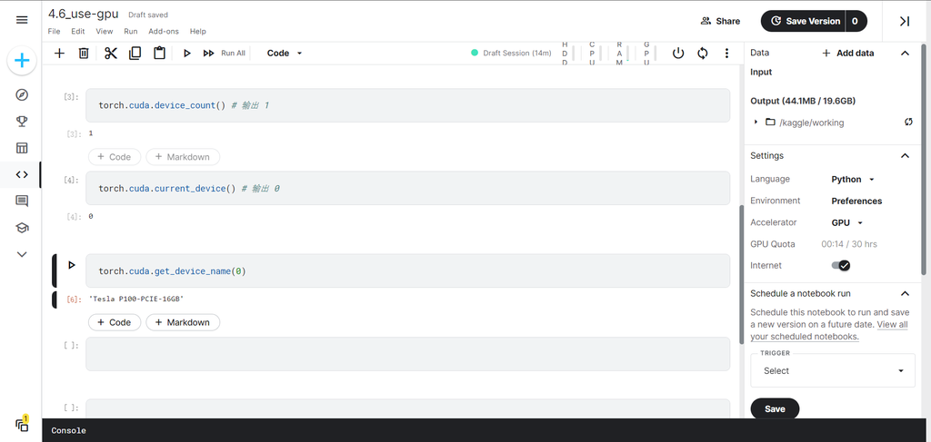